# Cheese Fat Level Prediction

Augus 08, 2022

Final Project Notebook by Xiao Juan Li

## Introduction

As we know, cheese is rich in essential nutrients, such as amino acids, protein, fatty acids, vitamins and minerals, but not all cheeses have the same nutritional benefits. Some cheeses are healthier than others. We want to find out these healthier cheeses.

Natural, low-fat, low-sodium cheese can make a healthful addition to most diets. From our dataset, we are going to make predictions on cheese fat level to answer whether this cheese is healthy or not. Apparently, this is a classification problem. In our dataset, we are more interested in those healthier cheeses with low fat. Thus we set positive label for "lower fat" in our target column "FatLevel".

## 1. Exploratory Data Analysis (EDA)

### 1.1 Data Imports

```python
# Import libraries needed for this task
from hashlib import sha1

import altair as alt
import graphviz
import numpy as np
import pandas as pd

from sklearn import tree
from sklearn.dummy import DummyClassifier
from sklearn.tree import DecisionTreeClassifier
from sklearn.model_selection import train_test_split, cross_validate
from sklearn.neighbors import KNeighborsClassifier
from sklearn.impute import SimpleImputer
from sklearn.pipeline import Pipeline, make_pipeline
from sklearn.compose import make_column_transformer
from sklearn.model_selection import GridSearchCV, RandomizedSearchCV
from sklearn.ensemble import RandomForestClassifier

from sklearn.preprocessing import (
    FunctionTransformer,
    Normalizer,
    OrdinalEncoder,
    OneHotEncoder,
    StandardScaler,
    normalize,
    scale)

from sklearn.svm import SVC
```

```python
# Import the dataset

cheese_df = pd.read_csv("data/cheese_data.csv")
cheese_df.head()
```

|  | CheeseId | ManufacturerProvCode | ManufacturingTypeEn | MoisturePercent | FlavourEn | CharacteristicsEn | Organic | CategoryTypeEn | MilkTypeEn | MilkTreatmentTypeEn | RindTypeEn | CheeseName | FatLevel |
| --- | --- | --- | --- | --- | --- | --- | --- | --- | --- | --- | --- | --- | --- |
| 0 | 228 | NB | Farmstead | 47.0 | Sharp, lactic | Uncooked | 0 | Firm Cheese | Ewe | Raw Milk | Washed Rind | Sieur de Duplessis (Le) | lower fat |
| 1 | 242 | NB | Farmstead | 47.9 | Sharp, lactic, lightly caramelized | Uncooked | 0 | Semi-soft Cheese | Cow | Raw Milk | Washed Rind | Tomme Le Champ Doré | lower fat |
| 2 | 301 | ON | Industrial | 54.0 | Mild, tangy, and fruity | Pressed and cooked cheese, pasta filata, inter... | 0 | Firm Cheese | Cow | Pasteurized | NaN | Provolone Sette Fette (Tre-Stelle) | lower fat |
| 3 | 303 | NB | Farmstead | 47.0 | Sharp with fruity notes and a hint of wild honey | NaN | 0 | Veined Cheeses | Cow | Raw Milk | NaN | Geai Bleu (Le) | lower fat |
| 4 | 319 | NB | Farmstead | 49.4 | Softer taste | NaN | 1 | Semi-soft Cheese | Cow | Raw Milk | Washed Rind | Gamin (Le) | lower fat |

```python
cheese_df.info()
```

```
<class 'pandas.core.frame.DataFrame'>
RangeIndex: 1042 entries, 0 to 1041
Data columns (total 13 columns):
 #   Column                Non-Null Count  Dtype
---  ------                --------------  -----
 0   CheeseId              1042 non-null   int64
 1   ManufacturerProvCode  1042 non-null   object
 2   ManufacturingTypeEn   1042 non-null   object
 3   MoisturePercent       1028 non-null   float64
 4   FlavourEn             801 non-null    object
 5   CharacteristicsEn     643 non-null    object
 6   Organic               1042 non-null   int64
 7   CategoryTypeEn        1019 non-null   object
 8   MilkTypeEn            1041 non-null   object
 9   MilkTreatmentTypeEn   977 non-null    object
 10  RindTypeEn            721 non-null    object
 11  CheeseName            1042 non-null   object
 12  FatLevel              1042 non-null   object
dtypes: float64(1), int64(2), object(10)
memory usage: 106.0+ KB
```

### 1.2 Data Splits

In order to avoid violating the golden rule, before we do anything with the data, let's split it. First we split the data into train_df (80%) and test_df (20%) and we keep the target column (FatLevel) in the splits so that we can use it in EDA.

```python
# Split the data

train_df, test_df = train_test_split(cheese_df, test_size=0.2, random_state=123)
```

```python
train_df.head()
```

|  | CheeseId | ManufacturerProvCode | ManufacturingTypeEn | MoisturePercent | FlavourEn | CharacteristicsEn | Organic | CategoryTypeEn | MilkTypeEn | MilkTreatmentTypeEn | RindTypeEn | CheeseName | FatLevel |
| --- | --- | --- | --- | --- | --- | --- | --- | --- | --- | --- | --- | --- | --- |
| 482 | 1506 | QC | Artisan | 48.0 | Sharp, hazelnutty | Pressed, surface-ripened | 0 | Semi-soft Cheese | Cow | Pasteurized | Washed Rind | Raclette Griffon | lower fat |
| 896 | 2055 | QC | Artisan | 45.0 | NaN | NaN | 0 | Veined Cheeses | Cow | Pasteurized | NaN | Rébellion 1837 | higher fat |
| 421 | 1445 | QC | Industrial | 50.0 | Mild | NaN | 0 | Soft Cheese | Cow | Pasteurized | Bloomy Rind | Mini-Brie | lower fat |
| 929 | 2141 | BC | Artisan | 40.0 | NaN | NaN | 0 | Semi-soft Cheese | Cow | Pasteurized | No Rind | Aged Farmhouse | higher fat |
| 737 | 1810 | QC | Artisan | 65.0 | Acidulous | Crumbly and soft texture, whitish | 0 | Fresh Cheese | Cow | Pasteurized | No Rind | Ricotta (l'Ancêtre) | lower fat |

Let's examine our train_df a bit by taking a look at the summary information.

```python
train_df.info()
```

```
<class 'pandas.core.frame.DataFrame'>
Int64Index: 833 entries, 482 to 1041
Data columns (total 13 columns):
 #   Column                Non-Null Count  Dtype
---  ------                --------------  -----
 0   CheeseId              833 non-null    int64
 1   ManufacturerProvCode  833 non-null    object
 2   ManufacturingTypeEn   833 non-null    object
 3   MoisturePercent       821 non-null    float64
 4   FlavourEn             637 non-null    object
 5   CharacteristicsEn     522 non-null    object
 6   Organic               833 non-null    int64
 7   CategoryTypeEn        813 non-null    object
 8   MilkTypeEn            832 non-null    object
 9   MilkTreatmentTypeEn   781 non-null    object
 10  RindTypeEn            579 non-null    object
 11  CheeseName            833 non-null    object
 12  FatLevel              833 non-null    object
dtypes: float64(1), int64(2), object(10)
memory usage: 91.1+ KB
```

```python
train_df.describe(include="all")
```

|  | CheeseId | ManufacturerProvCode | ManufacturingTypeEn | MoisturePercent | FlavourEn | CharacteristicsEn | Organic | CategoryTypeEn | MilkTypeEn | MilkTreatmentTypeEn | RindTypeEn | CheeseName | FatLevel |
| --- | --- | --- | --- | --- | --- | --- | --- | --- | --- | --- | --- | --- | --- |
| count | 833.000000 | 833 | 833 | 821.000000 | 637 | 522 | 833.000000 | 813 | 832 | 781 | 579 | 833 | 833 |
| unique | NaN | 10 | 3 | NaN | 515 | 446 | NaN | 6 | 8 | 3 | 4 | 830 | 2 |
| top | NaN | QC | Industrial | NaN | Mild | Creamy | NaN | Firm Cheese | Cow | Pasteurized | No Rind | Boerenkaas | lower fat |
| freq | NaN | 635 | 370 | NaN | 48 | 12 | NaN | 271 | 596 | 648 | 329 | 2 | 548 |
| mean | 1563.432173 | NaN | NaN | 47.052741 | NaN | NaN | 0.091236 | NaN | NaN | NaN | NaN | NaN | NaN |
| std | 445.350681 | NaN | NaN | 9.660351 | NaN | NaN | 0.288118 | NaN | NaN | NaN | NaN | NaN | NaN |
| min | 228.000000 | NaN | NaN | 12.000000 | NaN | NaN | 0.000000 | NaN | NaN | NaN | NaN | NaN | NaN |
| 25% | 1290.000000 | NaN | NaN | 40.000000 | NaN | NaN | 0.000000 | NaN | NaN | NaN | NaN | NaN | NaN |
| 50% | 1554.000000 | NaN | NaN | 46.000000 | NaN | NaN | 0.000000 | NaN | NaN | NaN | NaN | NaN | NaN |
| 75% | 1897.000000 | NaN | NaN | 52.000000 | NaN | NaN | 0.000000 | NaN | NaN | NaN | NaN | NaN | NaN |
| max | 2391.000000 | NaN | NaN | 92.000000 | NaN | NaN | 1.000000 | NaN | NaN | NaN | NaN | NaN | NaN |

From the above data summary, we can see there are 833 examples in our training data. There are 10 categorical columns and 3 numerical columns. The top 3 categorical features which have the most unique values are "CheeseName","FlavourEn" and "CharacteristicsEn".

Now let's find whether we have null values in the data and what columns have null values.

```python
print(train_df.isnull().sum())
```

```
CheeseId                  0
ManufacturerProvCode      0
ManufacturingTypeEn       0
MoisturePercent          12
FlavourEn               196
CharacteristicsEn       311
Organic                   0
CategoryTypeEn           20
MilkTypeEn                1
MilkTreatmentTypeEn      52
RindTypeEn              254
CheeseName                0
FatLevel                  0
dtype: int64
```

We find that some columns have missing values more than 20% of the entries, such as "FlavourEn","CharacteristicsEn" and "RindTypeEn". Also,"FlavourEn" and "CharacteristicsEn" are descriptive columns and we might consider dropping them in our analysis.

Now we are going to separate feature vectors from the targets.

Considering the relevance to the cheese fat level and the convenience, we are only going to use the folowing columns:

- `ManufacturerProvCode`
- `ManufacturingTypeEn`
- `MoisturePercent`
- `Organic`
- `CategoryTypeEn`
- `MilkTypeEn`
- `MilkTreatmentTypeEn`

and using `FatLevel` as the target column.

```python
X_train = train_df.drop(columns=['CheeseId', 'FlavourEn', 'CharacteristicsEn', 'RindTypeEn','CheeseName', 'FatLevel'])
y_train = train_df['FatLevel']

X_test = test_df.drop(columns=['CheeseId', 'FlavourEn', 'CharacteristicsEn', 'RindTypeEn','CheeseName', 'FatLevel'])
y_test = test_df['FatLevel']

X_train.head()
```

|  | ManufacturerProvCode | ManufacturingTypeEn | MoisturePercent | Organic | CategoryTypeEn | MilkTypeEn | MilkTreatmentTypeEn |
| --- | --- | --- | --- | --- | --- | --- | --- |
| 482 | QC | Artisan | 48.0 | 0 | Semi-soft Cheese | Cow | Pasteurized |
| 896 | QC | Artisan | 45.0 | 0 | Veined Cheeses | Cow | Pasteurized |
| 421 | QC | Industrial | 50.0 | 0 | Soft Cheese | Cow | Pasteurized |
| 929 | BC | Artisan | 40.0 | 0 | Semi-soft Cheese | Cow | Pasteurized |
| 737 | QC | Artisan | 65.0 | 0 | Fresh Cheese | Cow | Pasteurized |

### 1.3 Dataset Explores

- Class Distribution - Balanced or Not

Let's discover what the distribution of target values (FatLevel) in the train split looks like.

```python
class_dist = y_train.value_counts()
class_dist
```

```
lower fat     548
higher fat    285
Name: FatLevel, dtype: int64
```

There are two kinds of binary classification problems:

1)Distinguishing between two classes

2)Spotting a class (fraud transaction, spam, disease)

Obviously our data is a binary classification problem about distinguishing between two classes,"lower fat" or "higher fat".

```python
class_dist_df = pd.DataFrame({'FatLevel':class_dist.index, 'Count':class_dist.values})

plot_class_dist = alt.Chart(class_dist_df).mark_bar().encode(
                  alt.X('Count',title = 'Count of Fat Level'),
                  alt.Y('FatLevel',title = 'Fat Level')
                  ).properties(title = 'Count per Fat Level in Train Data')
plot_class_dist
```

[interactive chart not shown]

```python
class_pec_dist = y_train.value_counts(normalize =True)
class_pec_dist
```

```
lower fat     0.657863
higher fat    0.342137
Name: FatLevel, dtype: float64
```

Now let's take a close look at the class of our data. Is it balanced or not? If not, do we need to do imbalance correction?

First let's explore the rule of imbalanced. What counts as imbalanced? The answer could range from mild to extreme. According to Google Developers, the answer can be divided into 3 degrees of imbalance — mild (20–40%), moderate (1–20%), and extreme (<1%)

As we can see from the above class distribution percentage, the minority class "higher fat" is about 34%,so our data is mild imbalanced or relatively balanced and we might most likely skip the imbalance correction. It is different from the extreme imbalanced problem like fraud transaction, spam and etc.

- Features Exploration

Here we have a categorical column specifying different milk treatment type. We are interested in this feature because it is an important factor for cheese making.

```python
MilkTreatmentType_dist = X_train['MilkTreatmentTypeEn'].value_counts()
MilkTreatmentType_dist
```

```
Pasteurized    648
Raw Milk        91
Thermised       42
Name: MilkTreatmentTypeEn, dtype: int64
```

```python
pd.DataFrame(train_df['MilkTreatmentTypeEn'].value_counts()).rename(columns={'MilkTreatmentTypeEn': 'frequency'}).T
```

|  | Pasteurized | Raw Milk | Thermised |
| --- | --- | --- | --- |
| frequency | 648 | 91 | 42 |

```python
MilkTreatmentType_dist_df = pd.DataFrame({'MilkTreatmentType':MilkTreatmentType_dist.index, 'Count':MilkTreatmentType_dist.values})

plot_MilkTreatmentType_dist = alt.Chart(MilkTreatmentType_dist_df).mark_bar().encode(
                  alt.X('Count',title = 'Count per Type'),
                  alt.Y('MilkTreatmentType',title = 'Milk Treatment Type',sort='x')
                  ).properties(title = 'Count per Milk Treatment Type')
plot_MilkTreatmentType_dist
```

[interactive chart not shown]

From the above plot we find that "Pasteurized" is the most popular milk treatment type.

Why Pasteurized Milk?

Pasteurization is designed to kill off all bacteria and enzymes in the milk, good and bad, to provide something of a clean slate for the cheesemaker.

In order to better understand the milk treatment type,let's define them first.

- Raw milk: It has not been heated beyond 40 degrees Celsius (104 degrees Fahrenheit) and has not undergone any treatment that has an equivalent effect.
- Thermized milk: It has been heated to a temperature between 57 degrees and 68 degrees Celsius (135 to 154.4 degrees Fahrenheit) for at least 15 seconds.
- Pasteurized milk: It has undergone the process of heating every particle of milk, in properly designed and operated equipment, to a specific temperature for a set amount of time.

So we are going to set "MilkTreatMentTypeEn" as an ordinal feature and the order is as follows: (Considering the missing values we set "missing" as the lowest level for convienience)

```python
MilkTreatment_Type = ['missing','Raw Milk','Thermised','Pasteurized']
```

We can take a look at other categorical columns unique values.

```python
uniq_list_MilkType = train_df["MilkTypeEn"].unique()
uniq_list_MilkType
```

```
array(['Cow', 'Ewe and Goat', 'Goat', 'Ewe', 'Ewe and Cow',
       'Cow and Goat', nan, 'Cow, Goat and Ewe', 'Buffalo Cow'],
      dtype=object)
```

```python
uniq_list_CategoryType = train_df["CategoryTypeEn"].unique()
uniq_list_CategoryType
```

```
array(['Semi-soft Cheese', 'Veined Cheeses', 'Soft Cheese',
       'Fresh Cheese', 'Firm Cheese', nan, 'Hard Cheese'], dtype=object)
```

```python
uniq_list_ManufacturingType = train_df["ManufacturingTypeEn"].unique()
uniq_list_ManufacturingType
```

```
array(['Artisan', 'Industrial', 'Farmstead'], dtype=object)
```

It seems like column "Organic" is a binary feature. Let's find out its unique values.

```python
uniq_list_Organic = train_df["Organic"].unique()
uniq_list_Organic
```

```
array([0, 1])
```

It only contains 0 and 1. We can assume "Organic" as a binary feature.

- Null Values

```python
X_train.info()
```

```
<class 'pandas.core.frame.DataFrame'>
Int64Index: 833 entries, 482 to 1041
Data columns (total 7 columns):
 #   Column                Non-Null Count  Dtype
---  ------                --------------  -----
 0   ManufacturerProvCode  833 non-null    object
 1   ManufacturingTypeEn   833 non-null    object
 2   MoisturePercent       821 non-null    float64
 3   Organic               833 non-null    int64
 4   CategoryTypeEn        813 non-null    object
 5   MilkTypeEn            832 non-null    object
 6   MilkTreatmentTypeEn   781 non-null    object
dtypes: float64(1), int64(1), object(5)
memory usage: 52.1+ KB
```

From the above summary infomation,we can see that there are null values that need to be imputed for some of the columns.

SimpleImputer() is a transformer in sklearn which can deal with this problem.We can impute missing values in:

(1) Categorical columns: with the most frequent value.

(2) Numeric columns: with the mean or median of the column or a constant of our choosing.

### 2. Methods & Results

#### 2.1 Preprocessing and Pipelines Building

- Baseline

Let's make a baseline model using DummyClassifier.

Build a DummyClassifier named dummy using strategy='most_frequent'. Perform cross-validation on the training portion. Make sure that you return the training score using return_train_score=True.

Save the results in a dataframe named dummy_scores.

```python
dummy = DummyClassifier(strategy="most_frequent")
dummy_scores = pd.DataFrame(cross_validate(dummy, X_train, y_train, return_train_score=True))
dummy_scores
```

|  | fit_time | score_time | test_score | train_score |
| --- | --- | --- | --- | --- |
| 0 | 0.001950 | 0.000857 | 0.658683 | 0.657658 |
| 1 | 0.001320 | 0.000628 | 0.658683 | 0.657658 |
| 2 | 0.001428 | 0.000583 | 0.658683 | 0.657658 |
| 3 | 0.001246 | 0.000652 | 0.656627 | 0.658171 |
| 4 | 0.001256 | 0.000596 | 0.656627 | 0.658171 |

- Feature Types

We must fist identify the categorical and numeric columns. it’s a good idea to take a look at the categorical features we specified in more detail. Some of the categorical features are truly categorical, meaning that there is no ordinality among values.Some might have ordinality. From our previous analysis,we identify 4 types of features as follows.

```python
numeric_features = ["MoisturePercent"]

categorical_features = ["ManufacturerProvCode",
                        "ManufacturingTypeEn",
                         "CategoryTypeEn",
                         "MilkTypeEn"]

ordinal_features = ["MilkTreatmentTypeEn"]

binary_features = ["Organic"]
```

- Pipelines & Column Transformer

```python
numeric_transformer = make_pipeline(SimpleImputer(strategy="median"),
                                    StandardScaler())

categorical_transformer = make_pipeline(
    SimpleImputer(strategy="constant", fill_value="missing"),
    OneHotEncoder(handle_unknown="ignore")
)

ordinal_transformer = make_pipeline(
    SimpleImputer(strategy="constant", fill_value="missing"),
    OrdinalEncoder(categories=[MilkTreatment_Type], dtype=int,)
)

binary_transformer = make_pipeline(

    OneHotEncoder(drop="if_binary", dtype=int)
)
```

```python
preprocessor = make_column_transformer(
        (numeric_transformer, numeric_features),
        (categorical_transformer, categorical_features),
        (ordinal_transformer, ordinal_features),
        (binary_transformer, binary_features)
)
```

#### 2.2 Estimators(SVC & DecisionTreeClassifier & KNeighborsClassifier)

- SVC

```python
svc_pipe = make_pipeline(preprocessor, SVC(class_weight="balanced"))
svc_scores = pd.DataFrame(cross_validate(svc_pipe, X_train, y_train, return_train_score=True))
svc_scores
```

|  | fit_time | score_time | test_score | train_score |
| --- | --- | --- | --- | --- |
| 0 | 0.043221 | 0.015292 | 0.802395 | 0.804805 |
| 1 | 0.040715 | 0.014430 | 0.760479 | 0.806306 |
| 2 | 0.039743 | 0.014594 | 0.718563 | 0.813814 |
| 3 | 0.040591 | 0.014515 | 0.807229 | 0.796102 |
| 4 | 0.039935 | 0.014406 | 0.771084 | 0.811094 |

```python
svc_scores.mean()
```

```
fit_time       0.040841
score_time     0.014647
test_score     0.771950
train_score    0.806424
dtype: float64
```

- Decision Tree

```python
dt_pipe = make_pipeline(preprocessor, DecisionTreeClassifier(random_state=123,class_weight="balanced"))

dt_scores = pd.DataFrame(cross_validate(dt_pipe, X_train, y_train, return_train_score=True))

dt_scores
```

|  | fit_time | score_time | test_score | train_score |
| --- | --- | --- | --- | --- |
| 0 | 0.026189 | 0.011310 | 0.832335 | 0.953453 |
| 1 | 0.025833 | 0.011235 | 0.790419 | 0.954955 |
| 2 | 0.025234 | 0.011177 | 0.808383 | 0.950450 |
| 3 | 0.025516 | 0.011018 | 0.861446 | 0.946027 |
| 4 | 0.025392 | 0.011281 | 0.789157 | 0.947526 |

```python
dt_scores.mean()
```

```
fit_time       0.025633
score_time     0.011204
test_score     0.816348
train_score    0.950482
dtype: float64
```

- K Neighbors

```python
knn_pipe = make_pipeline(preprocessor, KNeighborsClassifier())
knn_scores = pd.DataFrame(cross_validate(knn_pipe, X_train, y_train, return_train_score=True))
knn_scores
```

|  | fit_time | score_time | test_score | train_score |
| --- | --- | --- | --- | --- |
| 0 | 0.022317 | 0.022768 | 0.802395 | 0.864865 |
| 1 | 0.021960 | 0.021994 | 0.778443 | 0.866366 |
| 2 | 0.021600 | 0.022750 | 0.802395 | 0.869369 |
| 3 | 0.022078 | 0.022119 | 0.813253 | 0.860570 |
| 4 | 0.021866 | 0.021449 | 0.813253 | 0.865067 |

```python
knn_scores.mean()
```

```
fit_time       0.021964
score_time     0.022216
test_score     0.801948
train_score    0.865248
dtype: float64
```

#### 2.3 Hyperparameters Tuning

As we know,accuracy is only part of the story,we want to make sure what the most important problem would be for our model to solve. In our case we want to take into account the f1-score.

We are exploring the healthier cheeses and want to make more correct predictions among all the predicted lower fat ones. At the same time, we want to identify the true lower fat healthier cheeses as many as possible. This means we care about both precision and recall score. Because f1-score combines precision and recall to give one score, thus we put our emphasis on f1-score in our hyperparameter tuning.

There are two optimization ways:

- Grid Search: It is great for spot-checking combinations that are known to perform well generally.
- Random Search: It is great for discovery and getting hyperparameter combinations that we would not have guessed intuitively, although it often requires more time to execute.

Because we use common estimators, we have some potential combinations that might perform well generally. Considering the efficiency, we are going to use Grid Search as our tuning option.

```python
# make our own scorer

from sklearn.metrics import f1_score, make_scorer
custom_scorer = make_scorer(f1_score, pos_label='lower fat')
```

- SVC Optimization

```python
svc_param_grid = {
    "svc__gamma": [0.1, 1.0, 10, 100],
    "svc__C": [0.1, 1.0, 10, 100]}

svc_grid_search = GridSearchCV(svc_pipe, svc_param_grid, cv=5, return_train_score=True, scoring=custom_scorer, n_jobs=-1);
svc_grid_search.fit(X_train, y_train);
svc_grid_search.best_params_
```

```
{'svc__C': 100, 'svc__gamma': 100}
```

```python
svc_grid_search.best_score_
```

```
0.8379316051950324
```

```python
svc_best_model = svc_grid_search.best_estimator_

svc_best_model.fit(X_train,y_train)

pd.DataFrame(cross_validate(svc_best_model, X_train, y_train, return_train_score=True)).mean()
```

```
fit_time       0.051000
score_time     0.017090
test_score     0.773104
train_score    0.950482
dtype: float64
```

```python
svc_best_model.score(X_test,y_test).round(2)
```

```
0.77
```

- Decision Tree Optimization

```python
dt_param_grid = {"decisiontreeclassifier__max_depth": [2, 5, 10, 20],
             "decisiontreeclassifier__min_samples_split": [2,4,6,10]}

dt_grid_search = GridSearchCV(dt_pipe, dt_param_grid, cv=5, return_train_score=True,scoring=custom_scorer,n_jobs=-1);
dt_grid_search.fit(X_train, y_train);
dt_grid_search.best_params_
```

```
{'decisiontreeclassifier__max_depth': 20,
 'decisiontreeclassifier__min_samples_split': 4}
```

```python
dt_grid_search.best_score_
```

```
0.8587198592247646
```

```python
dt_best_model = dt_grid_search.best_estimator_

dt_best_model.fit(X_train,y_train)

pd.DataFrame(cross_validate(dt_best_model, X_train, y_train, return_train_score=True)).mean()
```

```
fit_time       0.024873
score_time     0.011053
test_score     0.822336
train_score    0.931876
dtype: float64
```

```python
dt_best_model.score(X_test,y_test).round(2)
```

```
0.84
```

- K Neighbors Optimization

```python
knn_param_grid = {"kneighborsclassifier__n_neighbors": [3, 5, 10, 20]}

knn_grid_search = GridSearchCV(knn_pipe, knn_param_grid, cv=5, return_train_score=True,scoring=custom_scorer,n_jobs=-1);
knn_grid_search.fit(X_train, y_train);
knn_grid_search.best_params_
```

```
{'kneighborsclassifier__n_neighbors': 3}
```

```python
knn_grid_search.best_score_
```

```
0.8669929385083244
```

```python
knn_best_model = knn_grid_search.best_estimator_
knn_best_model.fit(X_train,y_train)
pd.DataFrame(cross_validate(knn_best_model, X_train, y_train, return_train_score=True)).mean()
```

```
fit_time       0.021179
score_time     0.021299
test_score     0.819941
train_score    0.884755
dtype: float64
```

```python
knn_best_model.score(X_test,y_test).round(2)
```

```
0.82
```

We basically use f1-score for hyperparameter scoring and it makes sense for our data because both precision and recall are important for us.

As we can see from the above scores, the difference between train score and validation score in svc_best_model is the biggest.It looks like svc_best_model is a bit more over_fitting. The knn_best_model performs well but it is still not as good as dt_best_model when it comes to validation score and test score. Overall, the dt_best_model has the best performance both on the validation score with 82% and on the test set with 84%.

Based on the above ayalysis, we decide to use DecisionTreeClassifier as our estimator and dt_best_model as our best performing model. Hyperparameters of dt_best_model are max_depth =20 and min_samples_split = 4.

#### 2.4 Confusion Matrix & Classification Report

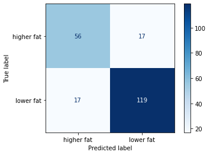

```python
from sklearn.metrics import plot_confusion_matrix,confusion_matrix,classification_report


dt_best_model.fit(X_train,y_train)

plot_confusion_matrix(dt_best_model, X_test, y_test, values_format="d", cmap="Blues");
```

```python
print(classification_report(y_test, dt_best_model.predict(X_test)))
```

```
              precision    recall  f1-score   support

  higher fat       0.77      0.77      0.77        73
   lower fat       0.88      0.88      0.88       136

    accuracy                           0.84       209
   macro avg       0.82      0.82      0.82       209
weighted avg       0.84      0.84      0.84       209
```

```python
predictions = dt_best_model.predict(X_test)
confusion_matrix(y_test, predictions)
TN, FP, FN, TP = confusion_matrix(y_test, predictions).ravel()
recall = TP / (TP + FN)
precision = TP / (TP + FP)
data = {}
data["accuracy"] = [(TP + TN) / (TN + FP + FN + TP)]
data["error"] = [(FP + FN) / (TN + FP + FN + TP)]
data["precision"] = [ TP / (TP + FP)]
data["recall"] = [TP / (TP + FN)]
data["f1 score"] = [(2 * precision * recall) / (precision + recall)]
measures_df = pd.DataFrame(data, index=['ourselves'])
measures_df
```

|  | accuracy | error | precision | recall | f1 score |
| --- | --- | --- | --- | --- | --- |
| ourselves | 0.837321 | 0.162679 | 0.875 | 0.875 | 0.875 |

From the above confusion matrix and classification report, we can see our model performs pretty well on precision score,recall score and f1 score equally. This is what we exactly want.

### Discussion

- Compare the best model to the baseline model

```python
dummy.fit(X_train,y_train)
dummy.score(X_test,y_test).round(2)
```

```
0.65
```

```python
dt_best_model.fit(X_train,y_train)
dt_best_model.score(X_test,y_test).round(2)
```

```
0.84
```

- Summaraiztion

Our best model performs much better than the baseline model. It uses preprocessing and pipelines to transform our raw data and use GridSearch with focus on f1-score to find the best hyperparameters. It concentrates on the precision score as well as recall score and has very decent balanced scores for our positive label "lower fat" in our calssification report.

The overall accuracy is 84%. It is such a well-rounded model that the precision,recall and f1 score are equally 88%. We want to find healthier cheeses as many as possible and as correct as possible. This model does a good job for us.

Also, the macro average score is 82% and the weighted average score is 84%. Using macro averages gives a more generalized performance measure irrespective of the class. As we mentioned before, our data is mild imbalanced or relatively balanced and the macro score is important to see if we did well enough in the minority class. 82% is a decent score for macro average. As for the weighted average score, the model performs well enough with 84% which is slightly better than the macro average.

In a word, our best model is based on Decision Tree estimator with f1-score tuning and it performs great in balancing all the scores in the classification report. It might not have a very high accuracy score but it is reallly well rounded. Undoubtedly, our best model serves us best for our purpose to find out more truly healthier cheeses with lower fat.

If given more detailed exploring and analysis, we might be able to use the descriptive columns like "CharacteristicsEn" and "FlavourEn" to find more connections to our target column. Also, we might be able to find out more ordinal features contributing to a better performance.

## References

Not all the work in this notebook is original. Parts that were borrowed from other resources are as follows:

### Resources used

- Module Contens about Classification Problems in Introduction to Machine Learning for inspiration
- Introducing and Exploring the dataset in Assignment 6 for inspiration
- Plot a bar chart in Assignment 8 for visualization inspiration
- [What is the healthiest cheese?](https://www.medicalnewstoday.com/articles/healthiest-cheese)
- [Raw, Thermized, or Pasteurized Milk for Cheesemaking](https://www.formaggiokitchen.com/blog/raw-thermized-or-pasteurized-milk-for-cheesemaking/)
- [Imbalanced Data from Google Developers](https://developers.google.com/machine-learning/data-prep/construct/sampling-splitting/imbalanced-data)
- [Hyperparameter Optimization With Random Search and Grid Search](https://machinelearningmastery.com/hyperparameter-optimization-with-random-search-and-grid-search/)
- [Macro average and weighted average meaning in classification_report](https://datascience.stackexchange.com/questions/65839/macro-average-and-weighted-average-meaning-in-classification-report)